# A complete multiverse analysis

Abhraneel Sarma

2019-07-22

## Introduction

In this document, we outline an initial approach to conducting a multiverse analysis in R. We will show how our package can be used to perform the multiverse analysis outlined by Steegen et al. in [Increasing Transparency Through a Multiverse Analysis](https://journals.sagepub.com/doi/pdf/10.1177/1745691616658637).

Data analysis can involve several decisions involving two or more options. In most statistical analysis, these decisions are taken by the researcher based on some reasonable justification. However, for several decisions, there can be more than one reasonable options to choose from. A multiverse analysis is a form of analysis which makes all such decisions explicit and conducts the complete analysis for all combinations of options (of each decision).

Below, we illustrate an example of a single analysis for a dataset. And then extend it to a multiverse analysis.

## The data

The first step is to read the raw data from the file and store it as a tibble. We will be following the *tidy data* format here. The data is stored in two text files, and we can use `readr` to read the files into R. In this example, we will use the data collected by *Durante et al.*, which investigated the effect of fertility on religiosity and political attitudes. We will focus on their second study (which we store in `data.raw.study2`).

```r
data("durante")

data.raw.study2 <- durante %>%
  mutate(
    Abortion = abs(7 - Abortion) + 1,
    StemCell = abs(7 - StemCell) + 1,
    Marijuana = abs(7 - Marijuana) + 1,
    RichTax = abs(7 - RichTax) + 1,
    StLiving = abs(7 - StLiving) + 1,
    Profit = abs(7 - Profit) + 1,
    FiscConsComp = FreeMarket + PrivSocialSec + RichTax + StLiving + Profit,
    SocConsComp = Marriage + RestrictAbortion + Abortion + StemCell + Marijuana
  )
```

The data look like this:

```r
data.raw.study2 %>%
  head(10)
```

```
## # A tibble: 10 x 26
##    WorkerID  Rel1  Rel2  Rel3 Abortion Marriage StemCell RestrictAbortion
##       <dbl> <dbl> <dbl> <dbl>    <dbl>    <dbl>    <dbl>            <dbl>
##  1        1     8     8     7        6        7        1                7
##  2        2     8     7     7        1        2        3                1
##  3        3     6     6     2        5        1        2                4
##  4        4     7     8     6        1        5        2                2
##  5        5     7     7     9        1        1        4                1
##  6        6     9     9     9        7        7        2                7
##  7        7     5     8     5        3        4        3                5
##  8        8     1     1     1        1        1        2                1
##  9        9     7     7     7        5        1        2                1
## 10       10     6     6     6        3        5        3                1
## # … with 18 more variables: Marijuana <dbl>, FreeMarket <dbl>,
## #   RichTax <dbl>, StLiving <dbl>, Profit <dbl>, PrivSocialSec <dbl>,
## #   Sure1 <dbl>, Sure2 <dbl>, Relationship <dbl>,
## #   ReportedCycleLength <dbl>, Vote <dbl>, Donate <dbl>,
## #   DateTesting <date>, StartDateofLastPeriod <date>,
## #   StartDateofPeriodBeforeLast <date>, StartDateNext <date>,
## #   FiscConsComp <dbl>, SocConsComp <dbl>
```

The original paper looked at the relationship between fertility, relationship status, and religiousity. But there are many reasonable ways to have defined each of these three variables from this dataset, so it is a good candidate for multiverse analysis.

## A single data set analysis: one possible analysis among many

The data collected needs to be processed before it can be modeled. Preparing the data set for analysis can involve several steps and decisions regarding how to encode the different raw values. The following is one example of data processing that can be performed for this study.

```r
one_universe = data.raw.study2 %>%
  mutate( ComputedCycleLength = StartDateofLastPeriod - StartDateofPeriodBeforeLast ) %>%
  mutate( NextMenstrualOnset = StartDateofLastPeriod + ComputedCycleLength ) %>%
  mutate(
    CycleDay = 28 - (NextMenstrualOnset - DateTesting),
    CycleDay = ifelse(CycleDay > 1 & CycleDay < 28, CycleDay, ifelse(CycleDay < 1, 1, 28))
  ) %>%
  mutate(
    Relationship = factor(ifelse(Relationship==1 | Relationship==2, "Single", "Relationship"))
  ) %>%
  filter( ComputedCycleLength > 25 & ComputedCycleLength < 35) %>%
  filter( Sure1 > 6 | Sure2 > 6 ) %>%
  mutate( Fertility = factor( ifelse(CycleDay >= 7 & CycleDay <= 14, "high", ifelse(CycleDay >= 17 & CycleDay <= 25, "low", "medium")) ) )
```

The transformed data for this one universe looks like this:

```r
one_universe %>%
  select( NextMenstrualOnset, Relationship, Sure1, Sure2, Fertility, everything() ) %>%
  head(10)
```

```
## # A tibble: 10 x 30
##    NextMenstrualOn… Relationship Sure1 Sure2 Fertility WorkerID  Rel1  Rel2
##    <date>           <fct>        <dbl> <dbl> <fct>        <dbl> <dbl> <dbl>
##  1 2012-06-17       Relationship     9     9 medium           1     8     8
##  2 2012-05-28       Relationship     9     7 low              2     8     7
##  3 2012-05-31       Relationship     8     7 low              3     6     6
##  4 2012-05-23       Single           8     8 medium           6     9     9
##  5 2012-05-31       Relationship     9     9 low              7     5     8
##  6 2012-06-15       Single           8     8 medium          11     2     5
##  7 2012-06-08       Relationship     9     8 high            12     7     7
##  8 2012-06-14       Relationship     9     8 medium          13     9     9
##  9 2012-06-10       Relationship     9     9 high            17     6     4
## 10 2012-06-18       Single           9     9 medium          18     9     9
## # … with 22 more variables: Rel3 <dbl>, Abortion <dbl>, Marriage <dbl>,
## #   StemCell <dbl>, RestrictAbortion <dbl>, Marijuana <dbl>,
## #   FreeMarket <dbl>, RichTax <dbl>, StLiving <dbl>, Profit <dbl>,
## #   PrivSocialSec <dbl>, ReportedCycleLength <dbl>, Vote <dbl>,
## #   Donate <dbl>, DateTesting <date>, StartDateofLastPeriod <date>,
## #   StartDateofPeriodBeforeLast <date>, StartDateNext <date>,
## #   FiscConsComp <dbl>, SocConsComp <dbl>, ComputedCycleLength <drtn>,
## #   CycleDay <dbl>
```

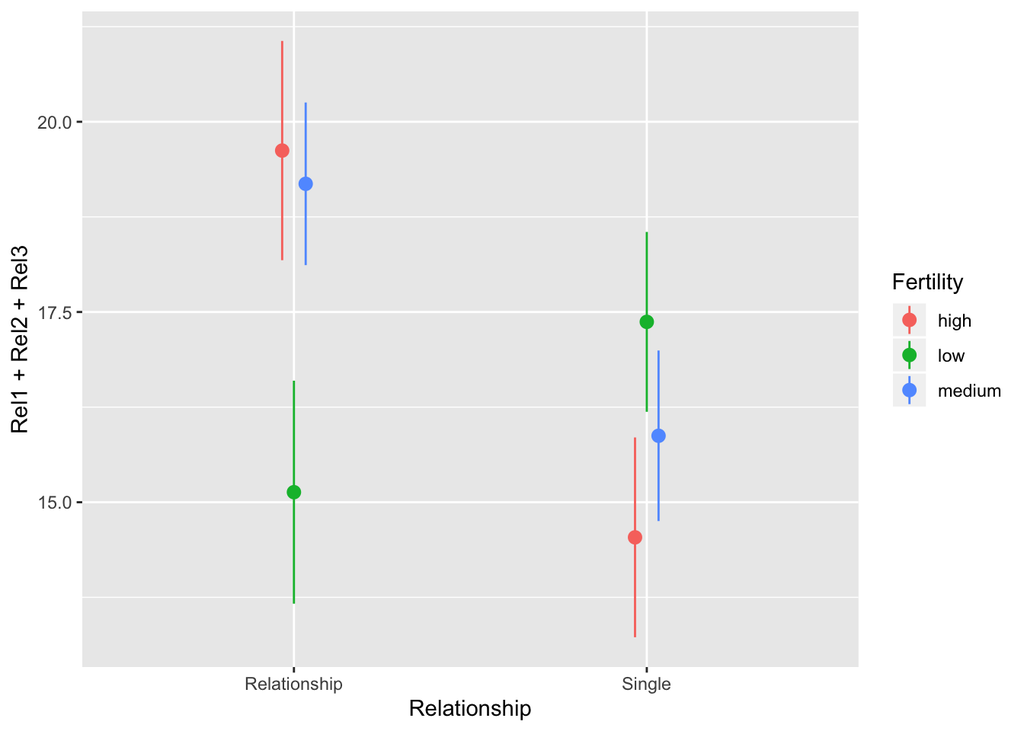

```r
one_universe %>%
  ggplot(aes(x = Relationship, y = Rel1 + Rel2 + Rel3, color = Fertility)) +
  stat_summary(position = position_dodge(width = .1), fun.data = "mean_se")
```

However, there also exists other valid processing options: instead of calculating `NextMenstrualOnset = StartDateofLastPeriod + ComputedCycleLength`, it can also be calculated as `StartDateofLastPeriod + ReportedCycleLength`. Such alternate processing options can exist for several decisions that a researcher makes in the data processing, analysis and presentation stages. This can thus result in a *multiverse of analysis*, with the one described above representing a single *universe*.

Below, we describe how our package allows you to conduct a multiverse analysis with ease.

## Defining the multiverse

`multidy` provides flexible functions which can be used to perform a multiverse analysis.

The first step is to define a *new multiverse*. We will use the multiverse object to create a set of universes, each representing a different way of analysing our data.

```r
M <- multiverse()
```

The next step is to define our possible analyses inside the multiverse. The `multidy` package includes functions that aim to make it easy to write multiverse analyses in as close a way to a single universe analysis as possible (as seen in the single analysis shown above).

Consider these first few lines from the transformation code in the single analysis above:

```r
df <- data.raw.study2 %>%
  mutate(ComputedCycleLength = StartDateofLastPeriod - StartDateofPeriodBeforeLast) %>%
  mutate(NextMenstrualOnset = StartDateofLastPeriod + ComputedCycleLength)
```

But `NextMenstrualOnset` could be calculated in at least two other reasonable ways:

- `NextMenstrualOnset = StartDateofLastPeriod + ReportedCycleLength`
- `NextMenstrualOnset = StartDateNext`

To create a multiverse that includes these three possible processing options, we can use the `branch()` function. The `branch()` function defines a *parameter* (here `menstrual_calculation`) and the different *options* that the parameter can take (here, `"mc_option1"`, `"mc_option2"`, `"mc_option3"`). Each option corresponds to a different chunk of code that would be executed in a different universe.

```r
NextMenstrualOnset = branch(menstrual_calculation,
  "mc_option1" ~ StartDateofLastPeriod + ComputedCycleLength,
  "mc_option2" ~ StartDateofLastPeriod + ReportedCycleLength,
  "mc_option3" ~ StartDateNext
)
```

The `branch()` function indicates that, *in our multiverse*, NextMenstrualOnset can take either of the three options (here, `"mc_option1"`, `"mc_option2"`, `"mc_option3"`). Thus, we need to declare this data processing step inside the multiverse. We do this by using the `inside()` function. The `inside()` function takes in two arguments: 1. the multiverse object, M; and 2. the code for the analysis (including branches), enclosed within `{}`

```r
inside(M, {
  df <- data.raw.study2  %>%
    mutate( ComputedCycleLength = StartDateofLastPeriod - StartDateofPeriodBeforeLast ) %>%
    mutate( NextMenstrualOnset = branch(menstrual_calculation,
      "mc_option1" ~ StartDateofLastPeriod + ComputedCycleLength,
      "mc_option2" ~ StartDateofLastPeriod + ReportedCycleLength,
      "mc_option3" ~ StartDateNext)
    )
})
```

Alternative to the `inside` function, we can use the more concise `<-` operator to define the multiverse. However, any expression on the right-hand-side of the `<-` operator needs to be preceded by the `~` (tilde) which converts the expression to a formula. Thus, the syntax looks like: `<multiverse_object>$<variable_name> <- ~ <expression>`

```r
M$df <- ~ data.raw.study2  %>%
  mutate( ComputedCycleLength = StartDateofLastPeriod - StartDateofPeriodBeforeLast ) %>%
    mutate(NextMenstrualOnset = branch(menstrual_calculation,
      "mc_option1" ~ StartDateofLastPeriod + ComputedCycleLength,
      "mc_option2" ~ StartDateofLastPeriod + ReportedCycleLength,
      "mc_option3" ~ StartDateNext)
    )
```

## The multiverse, with declared code and branches

Once you add the code to the multiverse, it automatically parses the code to identify the `parameters` and the corresponding `options` that have been defined for each parameter.

Once the code has been added, the `multiverse` object will have the following attributes:

1. `parameters`, which is a list of parameters

```r
parameters(M)
```

```
## $menstrual_calculation
## $menstrual_calculation[[1]]
## [1] "mc_option1"
##
## $menstrual_calculation[[2]]
## [1] "mc_option2"
##
## $menstrual_calculation[[3]]
## [1] "mc_option3"
```

2. `conditions`, which is a list of conditions (we’ll define this later)
3. `multiverse_table`, which is a tibble consisting of all possible combination of values for the multiverse

```r
multiverse_table(M)
```

```
## # A tibble: 3 x 4
##   menstrual_calculation .parameter_assignment .code      .results
##   <list>                <list>                <list>     <list>
## 1 <chr [1]>             <named list [1]>      <language> <env>
## 2 <chr [1]>             <named list [1]>      <language> <env>
## 3 <chr [1]>             <named list [1]>      <language> <env>
```

4. `current_parameter_assignment`, which is a list of one set of options for each parameter defined in the multiverse. It initialises to the first option for each parameter. This should be the default analysis.

```r
default_parameter_assignment(M)
```

```
## $menstrual_calculation
## [1] "mc_option1"
```

5. `code`, which is the code that the user passes to the multiverse to conduct a multiverse analysis. However, we do not execute this code and it is stored unevaluated. The user can interactively edit and rewrte this code, and can execute it for the current analysis or the entire multiverse using dedicated functions.

```r
code(M)
```

```
## {
##     df <- data.raw.study2 %>% mutate(ComputedCycleLength = StartDateofLastPeriod -
##         StartDateofPeriodBeforeLast) %>% mutate(NextMenstrualOnset = branch(menstrual_calculation,
##         "mc_option1" ~ StartDateofLastPeriod + ComputedCycleLength,
##         "mc_option2" ~ StartDateofLastPeriod + ReportedCycleLength,
##         "mc_option3" ~ StartDateNext))
## }
```

## Running a single analysis from the multiverse

At this point, we have defined three possible processing options (three universes) in our multiverse. Keeping consistency with the interactive programming interface of RStudio, we also execute the default analysis in each step. In the previous step, we stored the results in the variable `df`. We can see the result of this analysis in the appropriate row (universe) of the multiverse table.

```r
M$df %>% head()
```

```
## # A tibble: 6 x 28
##   WorkerID  Rel1  Rel2  Rel3 Abortion Marriage StemCell RestrictAbortion
##      <dbl> <dbl> <dbl> <dbl>    <dbl>    <dbl>    <dbl>            <dbl>
## 1        1     8     8     7        6        7        1                7
## 2        2     8     7     7        1        2        3                1
## 3        3     6     6     2        5        1        2                4
## 4        4     7     8     6        1        5        2                2
## 5        5     7     7     9        1        1        4                1
## 6        6     9     9     9        7        7        2                7
## # … with 20 more variables: Marijuana <dbl>, FreeMarket <dbl>,
## #   RichTax <dbl>, StLiving <dbl>, Profit <dbl>, PrivSocialSec <dbl>,
## #   Sure1 <dbl>, Sure2 <dbl>, Relationship <dbl>,
## #   ReportedCycleLength <dbl>, Vote <dbl>, Donate <dbl>,
## #   DateTesting <date>, StartDateofLastPeriod <date>,
## #   StartDateofPeriodBeforeLast <date>, StartDateNext <date>,
## #   FiscConsComp <dbl>, SocConsComp <dbl>, ComputedCycleLength <drtn>,
## #   NextMenstrualOnset <date>
```

## A multiverse with all possible combinations specified

Besides calculating the onset of the next menstruation cycle, there are other variables which have multiple valid and reasonable processing options. These include defining `Relationship` and `Fertility`, and exclusion criteria based on the values for cycle length and certainty of responses. The next code chunk illustrates how this can be added to the multiverse object defined above. We’ll also try the more concise `<-` assignment operator now.

```r
M$df <- ~ df %>%
    mutate(Relationship = branch( relationship_status,
      "rs_option1" ~ factor(ifelse(Relationship==1 | Relationship==2, 'Single', 'Relationship')),
      "rs_option2" ~ factor(ifelse(Relationship==1, 'Single', 'Relationship')),
      "rs_option3" ~ factor(ifelse(Relationship==1, 'Single', ifelse(Relationship==3 | Relationship==4, 'Relationship', NA))) )
    ) %>%
    mutate(
      CycleDay = 28 - (NextMenstrualOnset - DateTesting),
      CycleDay = ifelse(CycleDay > 1 & CycleDay < 28, CycleDay, ifelse(CycleDay < 1, 1, 28))
    ) %>%
    filter( branch(cycle_length,
      "cl_option1" ~ TRUE,
      "cl_option2" ~ ComputedCycleLength > 25 & ComputedCycleLength < 35,
      "cl_option3" ~ ReportedCycleLength > 25 & ReportedCycleLength < 35
    )) %>%
    filter( branch(certainty,
        "cer_option1" ~ TRUE,
        "cer_option2" ~ Sure1 > 6 | Sure2 > 6
    )) %>%
    mutate( Fertility = branch( fertile,
        "fer_option1" ~ factor( ifelse(CycleDay >= 7 & CycleDay <= 14, "high", ifelse(CycleDay >= 17 & CycleDay <= 25, "low", "medium")) ),
        "fer_option2" ~ factor( ifelse(CycleDay >= 6 & CycleDay <= 14, "high", ifelse(CycleDay >= 17 & CycleDay <= 27, "low", "medium")) ),
        "fer_option3" ~ factor( ifelse(CycleDay >= 9 & CycleDay <= 17, "high", ifelse(CycleDay >= 18 & CycleDay <= 25, "low", "medium")) ),
        "fer_option4" ~ factor( ifelse(CycleDay >= 8 & CycleDay <= 14, "high", "low") ),
        "fer_option5" ~ factor( ifelse(CycleDay >= 8 & CycleDay <= 17, "high", "low") )
    ))
```

Since the multiverse object has already been created and the one parameter has already been defined, the inside function will add to the previous code.

```r
code(M)
```

```
## {
##     df <- data.raw.study2 %>% mutate(ComputedCycleLength = StartDateofLastPeriod -
##         StartDateofPeriodBeforeLast) %>% mutate(NextMenstrualOnset = branch(menstrual_calculation,
##         "mc_option1" ~ StartDateofLastPeriod + ComputedCycleLength,
##         "mc_option2" ~ StartDateofLastPeriod + ReportedCycleLength,
##         "mc_option3" ~ StartDateNext))
##     df <- df %>% mutate(Relationship = branch(relationship_status,
##         "rs_option1" ~ factor(ifelse(Relationship == 1 | Relationship ==
##             2, "Single", "Relationship")), "rs_option2" ~ factor(ifelse(Relationship ==
##             1, "Single", "Relationship")), "rs_option3" ~ factor(ifelse(Relationship ==
##             1, "Single", ifelse(Relationship == 3 | Relationship ==
##             4, "Relationship", NA))))) %>% mutate(CycleDay = 28 -
##         (NextMenstrualOnset - DateTesting), CycleDay = ifelse(CycleDay >
##         1 & CycleDay < 28, CycleDay, ifelse(CycleDay < 1, 1,
##         28))) %>% filter(branch(cycle_length, "cl_option1" ~
##         TRUE, "cl_option2" ~ ComputedCycleLength > 25 & ComputedCycleLength <
##         35, "cl_option3" ~ ReportedCycleLength > 25 & ReportedCycleLength <
##         35)) %>% filter(branch(certainty, "cer_option1" ~ TRUE,
##         "cer_option2" ~ Sure1 > 6 | Sure2 > 6)) %>% mutate(Fertility = branch(fertile,
##         "fer_option1" ~ factor(ifelse(CycleDay >= 7 & CycleDay <=
##             14, "high", ifelse(CycleDay >= 17 & CycleDay <= 25,
##             "low", "medium"))), "fer_option2" ~ factor(ifelse(CycleDay >=
##             6 & CycleDay <= 14, "high", ifelse(CycleDay >= 17 &
##             CycleDay <= 27, "low", "medium"))), "fer_option3" ~
##             factor(ifelse(CycleDay >= 9 & CycleDay <= 17, "high",
##                 ifelse(CycleDay >= 18 & CycleDay <= 25, "low",
##                   "medium"))), "fer_option4" ~ factor(ifelse(CycleDay >=
##             8 & CycleDay <= 14, "high", "low")), "fer_option5" ~
##             factor(ifelse(CycleDay >= 8 & CycleDay <= 17, "high",
##                 "low"))))
## }
```

The `multiverse_table` will contain all the possible combinations of the parameter options that have been identified.

```r
multiverse_table(M) %>%
  head()
```

```
## # A tibble: 6 x 8
##   menstrual_calcu… relationship_st… cycle_length certainty fertile
##   <list>           <list>           <list>       <list>    <list>
## 1 <chr [1]>        <chr [1]>        <chr [1]>    <chr [1]> <chr […
## 2 <chr [1]>        <chr [1]>        <chr [1]>    <chr [1]> <chr […
## 3 <chr [1]>        <chr [1]>        <chr [1]>    <chr [1]> <chr […
## 4 <chr [1]>        <chr [1]>        <chr [1]>    <chr [1]> <chr […
## 5 <chr [1]>        <chr [1]>        <chr [1]>    <chr [1]> <chr […
## 6 <chr [1]>        <chr [1]>        <chr [1]>    <chr [1]> <chr […
## # … with 3 more variables: .parameter_assignment <list>, .code <list>,
## #   .results <list>
```

In our multiverse we have identified 5 options for calculating `fertility`, 3 options for calculating `menstrual calculation` and `relationship status` each, 3 wyas of excluding participants based on their `cycle length` and 2 ways of excluding participants based on the self-reported `certainty` of their responses.

```r
multiverse_table(M) %>% nrow()
```

```
## [1] 270
```

We can then inspect the default analysis the default single universe analysis from this multiverse:

```r
M$df %>%
  head()
```

```
## # A tibble: 6 x 30
##   WorkerID  Rel1  Rel2  Rel3 Abortion Marriage StemCell RestrictAbortion
##      <dbl> <dbl> <dbl> <dbl>    <dbl>    <dbl>    <dbl>            <dbl>
## 1        1     8     8     7        6        7        1                7
## 2        2     8     7     7        1        2        3                1
## 3        3     6     6     2        5        1        2                4
## 4        4     7     8     6        1        5        2                2
## 5        5     7     7     9        1        1        4                1
## 6        6     9     9     9        7        7        2                7
## # … with 22 more variables: Marijuana <dbl>, FreeMarket <dbl>,
## #   RichTax <dbl>, StLiving <dbl>, Profit <dbl>, PrivSocialSec <dbl>,
## #   Sure1 <dbl>, Sure2 <dbl>, Relationship <fct>,
## #   ReportedCycleLength <dbl>, Vote <dbl>, Donate <dbl>,
## #   DateTesting <date>, StartDateofLastPeriod <date>,
## #   StartDateofPeriodBeforeLast <date>, StartDateNext <date>,
## #   FiscConsComp <dbl>, SocConsComp <dbl>, ComputedCycleLength <drtn>,
## #   NextMenstrualOnset <date>, CycleDay <dbl>, Fertility <fct>
```

## Specifying conditions in the multiverse analysis

In a multiverse analysis, it may occur that the value of one variable might depend on the value of another variable defined previously. For example, in our example, we are excluding participants based on their *cycle length*. This can be done in two ways: we can use the values of the variable,`ComputedCycleLength` or `ReportedCycleLength`. If we are using `ComputedCycleLength` to exclude participants, this means that we should not calculate the variable `NextMenstrualOnset` (date for the onset of the next menstrual cycle) using the `ReportedCycleLength` value. Similarly, if we are using `ReportedCycleLength` to exclude participants it is inconsistent to calculate `NextMenstrualOnset` using `ComputedCycleLength`.

We should be able to express these conditions in the multiverse. We can do this in two ways: 1. `%when%`: when declaring a branch, we can use this operator to specify the conditional $A | B$ as `A %when% B`. The conditional $A | B$ is also referred to as the connective $A \implies B$. This has the meaning “if A is true, then B is also true” and is an abbreviation for $\neg A | B$ 2. `branch_assert`: this function allows the user to specify any condition in the form of a logical operation

#### The %when% operator

There are two ways in which you can specify the `%when%` operator. The first is to specify it at the end of the branch. This will work even if you omit the branch option name.

```r
M$df <- data.raw.study2  %>%
    mutate( ComputedCycleLength = StartDateofLastPeriod - StartDateofPeriodBeforeLast ) %>%
    mutate(NextMenstrualOnset = branch(menstrual_calculation,
            "mc_option1" ~ (StartDateofLastPeriod + ComputedCycleLength) %when% (cycle_length != "cl_option3"),
            "mc_option2" ~ (StartDateofLastPeriod + ReportedCycleLength) %when% (cycle_length != "cl_option2"),
            "mc_option3" ~ StartDateNext)
    )
```

The other is to specify it at the head of the branch, right after the option name:

```r
M$df <- df  %>%
    mutate(NextMenstrualOnset = branch(menstrual_calculation,
            "mc_option1" %when% (cycle_length != "cl_option3") ~ StartDateofLastPeriod + ComputedCycleLength,
            "mc_option2" %when% (cycle_length != "cl_option2") ~ (StartDateofLastPeriod + ReportedCycleLength),
            "mc_option3" ~ StartDateNext)
    )
```

#### The `branch_assert()` function

Within the branch assert function, the user can specify any logical operation.

```r
M$df <- df  %>%
    mutate(NextMenstrualOnset = branch(menstrual_calculation,
            "mc_option1" ~ StartDateofLastPeriod + ComputedCycleLength,
            "mc_option2" ~ StartDateofLastPeriod + ReportedCycleLength,
            "mc_option3" ~ StartDateNext)
    ) %>%
    branch_assert( ! (menstrual_calculation == "mc_option1" & cycle_length == "cl_option3")) %>%
    branch_assert( !(menstrual_calculation == "mc_option2" & cycle_length != "cl_option2"))
```

Specifying these conditions allows us to exclude inconsistent combinations from our analyses. Let’s update our example by including these cnditions:

```r
M = multiverse()
M$df <- ~ data.raw.study2  %>%
    mutate( ComputedCycleLength = StartDateofLastPeriod - StartDateofPeriodBeforeLast )  %>%
    dplyr::filter( branch(cycle_length,
            "cl_option1" ~ TRUE,
            "cl_option2" ~ ComputedCycleLength > 25 & ComputedCycleLength < 35,
            "cl_option3" ~ ReportedCycleLength > 25 & ReportedCycleLength < 35
    )) %>%
    dplyr::filter( branch(certainty,
            "cer_option1" ~ TRUE,
            "cer_option2" ~ Sure1 > 6 | Sure2 > 6
    )) %>%
    mutate(NextMenstrualOnset = branch(menstrual_calculation,
            "mc_option1" %when% (cycle_length != "cl_option3") ~ StartDateofLastPeriod + ComputedCycleLength,
            "mc_option2" %when% (cycle_length != "cl_option2") ~ StartDateofLastPeriod + ReportedCycleLength,
            "mc_option3" ~ StartDateNext)
    )  %>%
    mutate(
      CycleDay = 28 - (NextMenstrualOnset - DateTesting),
      CycleDay = ifelse(CycleDay > 1 & CycleDay < 28, CycleDay, ifelse(CycleDay < 1, 1, 28))
    ) %>%
    mutate( Fertility = branch( fertile,
            "fer_option1" ~ factor( ifelse(CycleDay >= 7 & CycleDay <= 14, "high", ifelse(CycleDay >= 17 & CycleDay <= 25, "low", NA)) ),
            "fer_option2" ~ factor( ifelse(CycleDay >= 6 & CycleDay <= 14, "high", ifelse(CycleDay >= 17 & CycleDay <= 27, "low", NA)) ),
            "fer_option3" ~ factor( ifelse(CycleDay >= 9 & CycleDay <= 17, "high", ifelse(CycleDay >= 18 & CycleDay <= 25, "low", NA)) ),
            "fer_option4" ~ factor( ifelse(CycleDay >= 8 & CycleDay <= 14, "high", "low") ),
            "fer_option45" ~ factor( ifelse(CycleDay >= 8 & CycleDay <= 17, "high", "low") )
    )) %>%
    mutate(RelationshipStatus = branch(relationship_status,
            "rs_option1" ~ factor(ifelse(Relationship==1 | Relationship==2, 'Single', 'Relationship')),
            "rs_option2" ~ factor(ifelse(Relationship==1, 'Single', 'Relationship')),
            "rs_option3" ~ factor(ifelse(Relationship==1, 'Single', ifelse(Relationship==3 | Relationship==4, 'Relationship', NA))) )
    )
```

After excluding the inconsistent choice combinations, $270 − 2 \times (5 \times 1 \times 3 \times 1 \times 2) = 210$ choice combinations remain:

```r
multiverse_table(M) %>% nrow()
```

```
## [1] 210
```

Now, we’ve created the complete multiverse that was presented as example #2 from Steegen et al.’s paper.

## Modeling

Steegen et al. create 6 models. The first model uses data from example #1. The other five models use the data from example #2, which we’ve using so far.

### Model #2: Effect of Fertility and Relationship status on Religiosity

The authors compute a composite score of Religiosity by calculating the average of the three Religiosity items.

```r
M$df <- ~ df %>%
  mutate( RelComp = round((Rel1 + Rel2 + Rel3)/3, 2))
```

The authors perform an ANOVA to study the effect of *Fertility*, *Relationship* and their interaction term, on the composite Religiosity score. We fit the linear model using the call: `lm( RelComp ~ Fertility * RelationshipStatus, data = df )` inside our multiverse and save the result to a variable called `fit_RelComp`.

```r
M$fit_RelComp <- ~ lm( RelComp ~ Fertility * RelationshipStatus, data = df )
```

To extract the results from the analysis, we first create a tidy data-frame of the results of the model, using `broom::tidy`. Recall that declaring a variable in the multiverse only executes it in the default universe, and hence we need to call `execute_multiverse` to execute our analysis in each multiverse.

```r
M$summary_RelComp <- ~ fit_RelComp %>%
  broom::tidy( conf.int = TRUE )

execute_multiverse(M)
```

Now that we have performed the analysis in each universe of the multiverse, we need to plot the data. To plot the data, we need to extract the relevant result data-frame from each universe into a single data-frame. The following code does this, by extracting the variable where the estimates of the model are stored, `summary_RelComp` and creating a single tidy data-frame that can be accessed easily.

```r
multiverse_table(M) %>%
  mutate( index = seq(1:nrow(.)) ) %>%
  unnest( map(.results, "summary_RelComp" ) ) %>%
  head( 10 )
```

```
## # A tibble: 10 x 8
##    index term      estimate std.error statistic  p.value conf.low conf.high
##    <int> <chr>        <dbl>     <dbl>     <dbl>    <dbl>    <dbl>     <dbl>
##  1     1 (Interce…     6.37     0.404     15.8  4.21e-41    5.58     7.17
##  2     1 Fertilit…    -1.20     0.535     -2.24 2.57e- 2   -2.25    -0.147
##  3     1 Relation…    -1.46     0.540     -2.70 7.34e- 3   -2.52    -0.395
##  4     1 Fertilit…     2.03     0.716      2.84 4.89e- 3    0.621    3.44
##  5     2 (Interce…     6.31     0.470     13.4  8.07e-31    5.38     7.24
##  6     2 Fertilit…    -1.22     0.612     -2.00 4.66e- 2   -2.43    -0.0187
##  7     2 Relation…    -1.49     0.614     -2.42 1.64e- 2   -2.70    -0.275
##  8     2 Fertilit…     2.09     0.814      2.57 1.09e- 2    0.485    3.69
##  9     3 (Interce…     6.56     0.450     14.6  9.13e-35    5.68     7.45
## 10     3 Fertilit…    -1.46     0.599     -2.44 1.55e- 2   -2.64    -0.281
```

We then take this data frame and plot the results as a confidence interval and point estimate using `ggplot2`. As you can see, this is similar to how you would plot a point estimate and confidence intervals for a regular analysis. We then use `gganimate` to animate through the results of each universe to quickly get an overview of the robustness of the results.

[output not shown]

[output not shown]

[output cut: 47 more lines]

[output not shown]

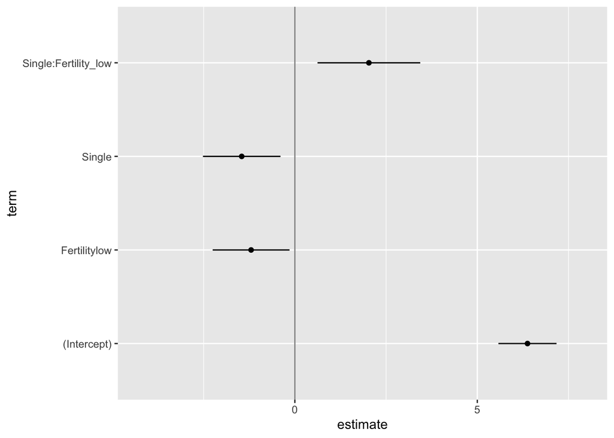

```r
multiverse_table(M) %>%
  mutate( index = seq(1:nrow(.)) ) %>%
  unnest( map(.results, "summary_RelComp" ) ) %>%
  mutate( term = recode( term,
                 "RelationshipStatusSingle" = "Single",
                 "Fertilitylow:RelationshipStatusSingle" = "Single:Fertility_low"
  ) ) %>%
  ggplot() +
  geom_vline( xintercept = 0,  colour = '#979797' ) +
  geom_point( aes(x = estimate, y = term)) +
  geom_errorbarh( aes(xmin = conf.low, xmax = conf.high, y = term), height = 0) +
  transition_states( index )
```

### Models #3 - 6

The authors also perform a number of other analysis using the same independent variables (`Fertility`, `Relationship Status` and their interaction term), but with different dependent variables: `Fiscal political attitudes`, `Social political attitudes`, `Voting preferences` and `Donation preferences`. Below we perform these analyses and visualize the results.

```r
M$fit_FiscConsComp <- ~ lm( FiscConsComp ~ Fertility * RelationshipStatus, data = df)
M$summary_FiscConsComp <- ~ fit_FiscConsComp %>%
  broom::tidy( conf.int = TRUE )

M$fit_SocConsComp <- ~ lm( SocConsComp ~ Fertility * RelationshipStatus, data = df)
M$summary_SocConsComp <- ~ fit_SocConsComp %>%
  broom::tidy( conf.int = TRUE )

M$fit_Donate <- ~ glm( Donate ~ Fertility * Relationship, data = df, family = binomial(link = "logit") )
M$summary_Donate <- ~ fit_Donate %>%
  broom::tidy( conf.int = TRUE )

M$fit_Vote <- ~ glm( Vote ~ Fertility * Relationship, data = df, family = binomial(link = "logit") )
M$summary_Vote <- ~ fit_Vote %>%
  broom::tidy( conf.int = TRUE )

execute_multiverse(M)
```

### Model #3: Effect of Fertility and Relationship status on Fiscal political attitudes

[output not shown]

[output not shown]

[output cut: 47 more lines]

[output not shown]

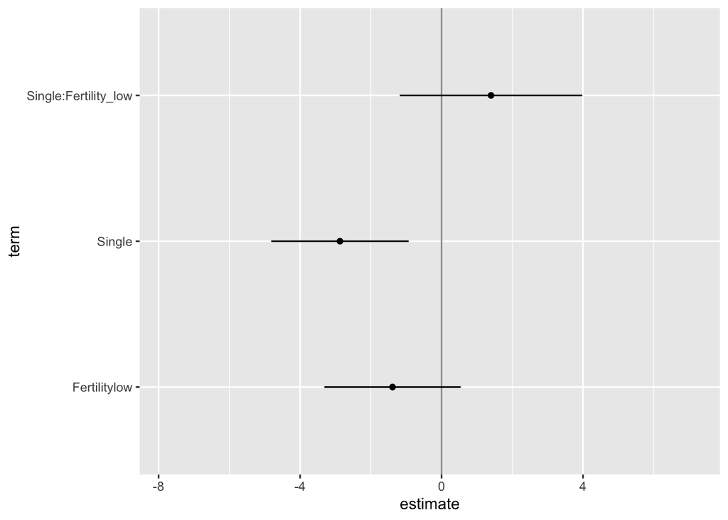

```r
multiverse_table(M) %>%
  mutate( index = seq(1:nrow(.)) ) %>%
  unnest( map(.results, "summary_FiscConsComp" ) ) %>%
  mutate( term = recode( term,
                 "RelationshipStatusSingle" = "Single",
                 "Fertilitylow:RelationshipStatusSingle" = "Single:Fertility_low"
  ) ) %>%
  filter( term != "(Intercept)" ) %>%
  ggplot() +
  geom_vline( xintercept = 0,  colour = '#979797' ) +
  geom_point( aes(x = estimate, y = term)) +
  geom_errorbarh( aes(xmin = conf.low, xmax = conf.high, y = term), height = 0) +
  transition_states( index )
```

### Model #4: Effect of Fertility and Relationship status on Social political attitudes

[output not shown]

[output not shown]

[output cut: 47 more lines]

[output not shown]

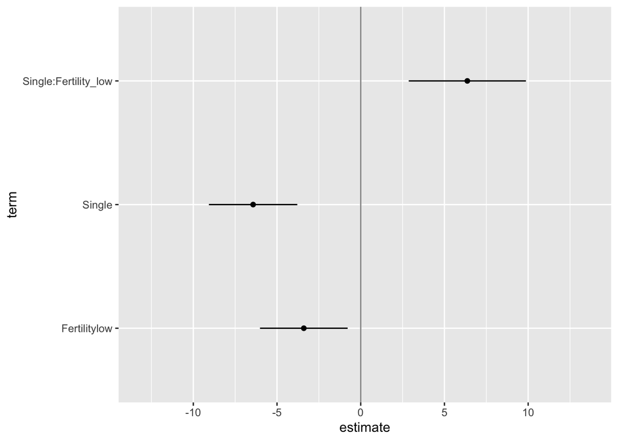

```r
multiverse_table(M) %>%
  mutate( index = seq(1:nrow(.)) ) %>%
  unnest( map(.results, "summary_SocConsComp" ) ) %>%
  mutate( term = recode( term,
                 "RelationshipStatusSingle" = "Single",
                 "Fertilitylow:RelationshipStatusSingle" = "Single:Fertility_low"
  ) ) %>%
  filter( term !=  "(Intercept)") %>%
  ggplot() +
  geom_vline( xintercept = 0,  colour = '#979797' ) +
  geom_point( aes(x = estimate, y = term)) +
  geom_errorbarh( aes(xmin = conf.low, xmax = conf.high, y = term), height = 0) +
  transition_states( index )
```

[output not shown]

[output not shown]

[output cut: 47 more lines]

[output not shown]

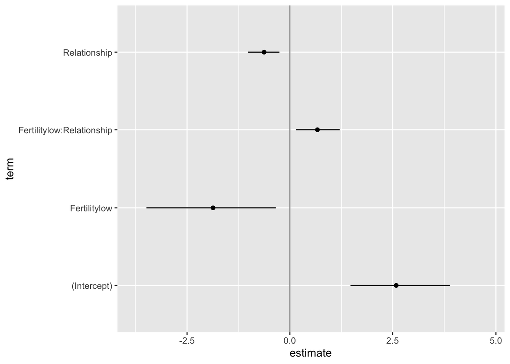

```r
multiverse_table(M) %>%
  mutate( index = seq(1:nrow(.)) ) %>%
  unnest( map(.results, "summary_Donate" ) ) %>%
  mutate( term = recode( term,
                 "RelationshipStatusSingle" = "Single",
                 "Fertilitylow:RelationshipStatusSingle" = "Single:Fertility_low"
  ) ) %>%
  filter( index %in% sample(1:210, 10) ) %>%
  ggplot() +
  geom_vline( xintercept = 0,  colour = '#979797' ) +
  geom_point( aes(x = estimate, y = term)) +
  geom_errorbarh( aes(xmin = conf.low, xmax = conf.high, y = term), height = 0) +
  transition_states( index )
```

[output not shown]

[output cut: 9 more lines]

[output not shown]

[output not shown]

[output cut: 47 more lines]

[output not shown]

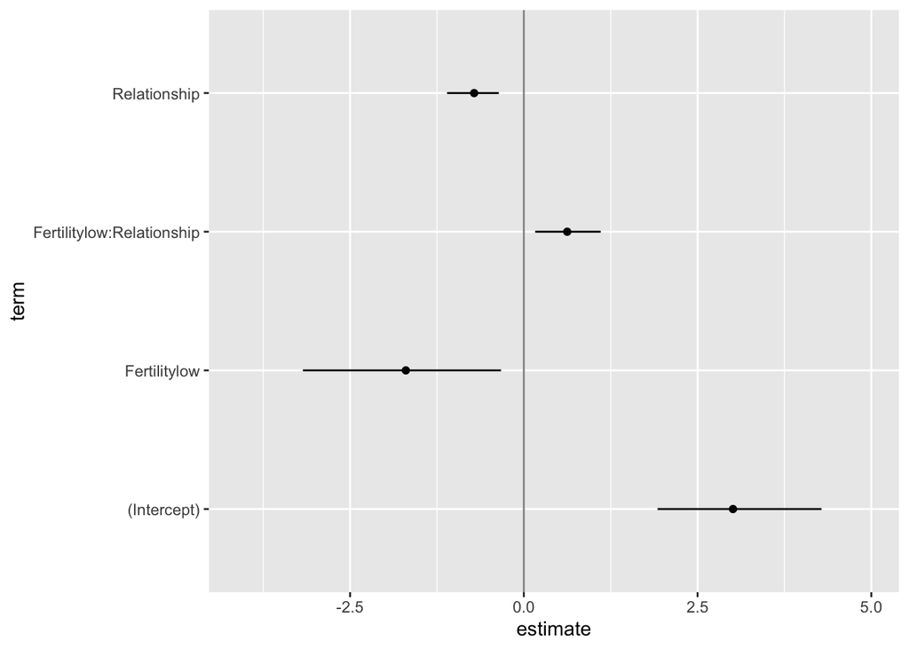

```r
multiverse_table(M) %>%
  mutate( index = seq(1:nrow(.)) ) %>%
  unnest( map(.results, "summary_Vote" ) ) %>%
  mutate( term = recode( term,
                 "RelationshipStatusSingle" = "Single",
                 "Fertilitylow:RelationshipStatusSingle" = "Single:Fertility_low"
  ) ) %>%
  filter( index %in% sample(1:210, 10) ) %>%
  ggplot() +
  geom_vline( xintercept = 0,  colour = '#979797' ) +
  geom_point( aes(x = estimate, y = term)) +
  geom_errorbarh( aes(xmin = conf.low, xmax = conf.high, y = term), height = 0) +
  transition_states( index )
```